# LAB1

Shritama Sengupta

2023-08-08

### Loading required libraries

```r
library(corrplot)
library(ggplot2)
library(GGally)
```

### 1.

### Laoding data

```r
df = data <- read.csv("C:/Users/shrit/Downloads/Ass-1_Dataset_Largest companay yields - Sheet1.csv")
```

### Renaming columns

```r
colnames(df)
```

```
## [1] "Company"           "Sales.billions."   "Profits.billions."
## [4] "Assets.Billions."
```

```r
newnames = c("company", "sales", "profits", "assets")
colnames(df) = newnames

df
```

```
##                company  sales profits  assets
## 1            Citigroup 108.28   17.05 1484.10
## 2    Generala Electric 152.36   16.59  750.33
## 3  American Intl Group  95.04   10.91  766.42
## 4      Bank of America  65.45   14.14  110.46
## 5           HSBC group  62.97    9.52 1031.29
## 6          Exxon Mobil 263.99   25.33  195.26
## 7    Royal Dutch/Shell 265.19   18.54  193.83
## 8                   BP 185.06   15.73  191.11
## 9            ING Group  92.01      NA 1175.16
## 10        Toyota Motor 165.68   11.13  211.15
```

### Replacing null values

```r
# Replacing the null value
profits_mean <- mean(df$profits, na.rm = TRUE)
na_indices <- which(is.na(df$profits))
df$profits[na_indices] <- profits_mean

print(df)
```

```
##                company  sales  profits  assets
## 1            Citigroup 108.28 17.05000 1484.10
## 2    Generala Electric 152.36 16.59000  750.33
## 3  American Intl Group  95.04 10.91000  766.42
## 4      Bank of America  65.45 14.14000  110.46
## 5           HSBC group  62.97  9.52000 1031.29
## 6          Exxon Mobil 263.99 25.33000  195.26
## 7    Royal Dutch/Shell 265.19 18.54000  193.83
## 8                   BP 185.06 15.73000  191.11
## 9            ING Group  92.01 15.43778 1175.16
## 10        Toyota Motor 165.68 11.13000  211.15
```

```r
attach(df)
```

### Summary Statistics

```r
# Summary
summary(sales)
```

```
##    Min. 1st Qu.  Median    Mean 3rd Qu.    Max.
##   62.97   92.77  130.32  145.60  180.22  265.19
```

```r
summary(profits)
```

```
##    Min. 1st Qu.  Median    Mean 3rd Qu.    Max.
##    9.52   11.88   15.58   15.44   16.93   25.33
```

```r
summary(assets)
```

```
##    Min. 1st Qu.  Median    Mean 3rd Qu.    Max.
##   110.5   194.2   480.7   610.9   965.1  1484.1
```

### 2.

### Correlation Plot

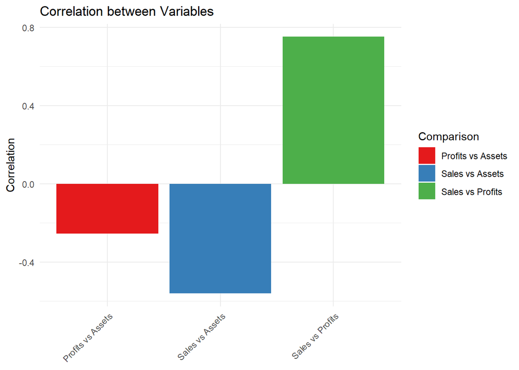

```r
# Correlation Analysis

# Calculating correlations
cor_sales_profits <- cor(data$Sales, data$Profits, use = "complete.obs")
cor_sales_assets <- cor(data$Sales, data$Assets, use = "complete.obs")
cor_profits_assets <- cor(data$Profits, data$Assets, use = "complete.obs")

# a data frame for correlations
correlation_data <- data.frame(
  Comparison = c("Sales vs Profits", "Sales vs Assets", "Profits vs Assets"),
  Correlation = c(cor_sales_profits, cor_sales_assets, cor_profits_assets)
)

# a colorful and attractive correlation plot
correlation_plot <- ggplot(correlation_data, aes(x = Comparison, y = Correlation, fill = Comparison)) +
  geom_bar(stat = "identity") +
  labs(title = "Correlation between Variables", x = NULL, y = "Correlation") +
  scale_fill_brewer(palette = "Set1") +
  theme_minimal() +
  theme(axis.text.x = element_text(angle = 45, hjust = 1))

# Displaying the plot
correlation_plot
```

### Scatter Plot

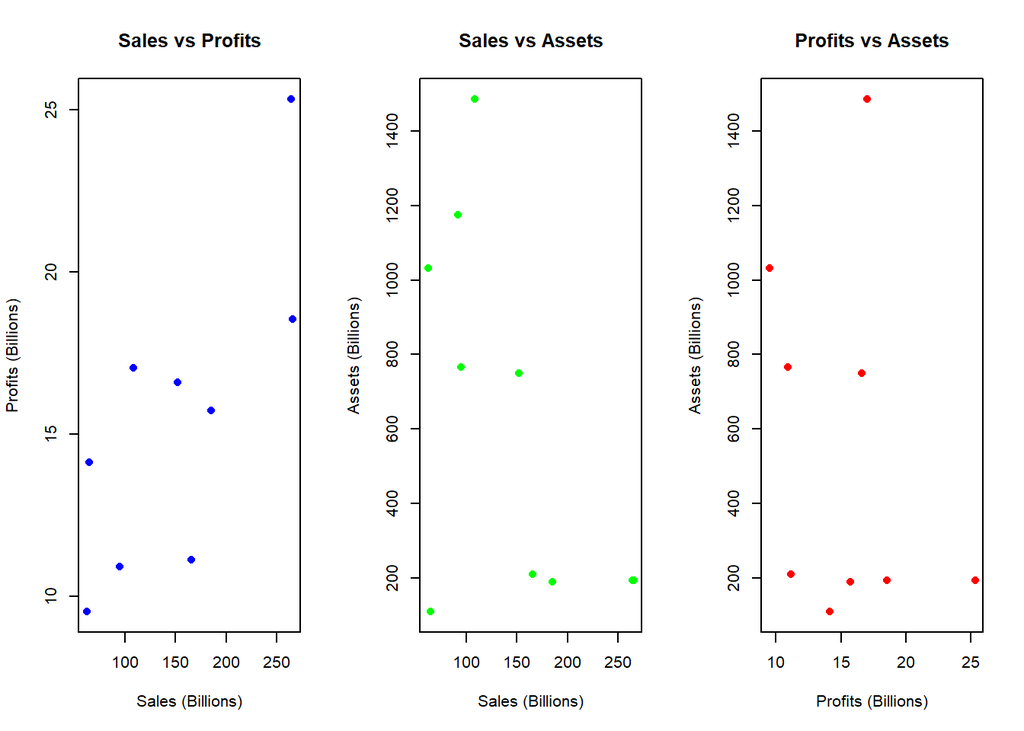

```r
# Creating a new plot window
par(mfrow = c(1, 3))  # Divide the plot area into 1 row and 3 columns

# Scatter plot: Sales vs Profits
plot(data$Sales, data$Profits, pch = 16, col = "blue",
     main = "Sales vs Profits", xlab = "Sales (Billions)", ylab = "Profits (Billions)")

# Scatter plot: Sales vs Assets
plot(data$Sales, data$Assets, pch = 16, col = "green",
     main = "Sales vs Assets", xlab = "Sales (Billions)", ylab = "Assets (Billions)")

# Scatter plot: Profits vs Assets
plot(data$Profits, data$Assets, pch = 16, col = "red",
     main = "Profits vs Assets", xlab = "Profits (Billions)", ylab = "Assets (Billions)")
```

```r
# Reset plot layout
par(mfrow = c(1, 1))
```

### PairPlots

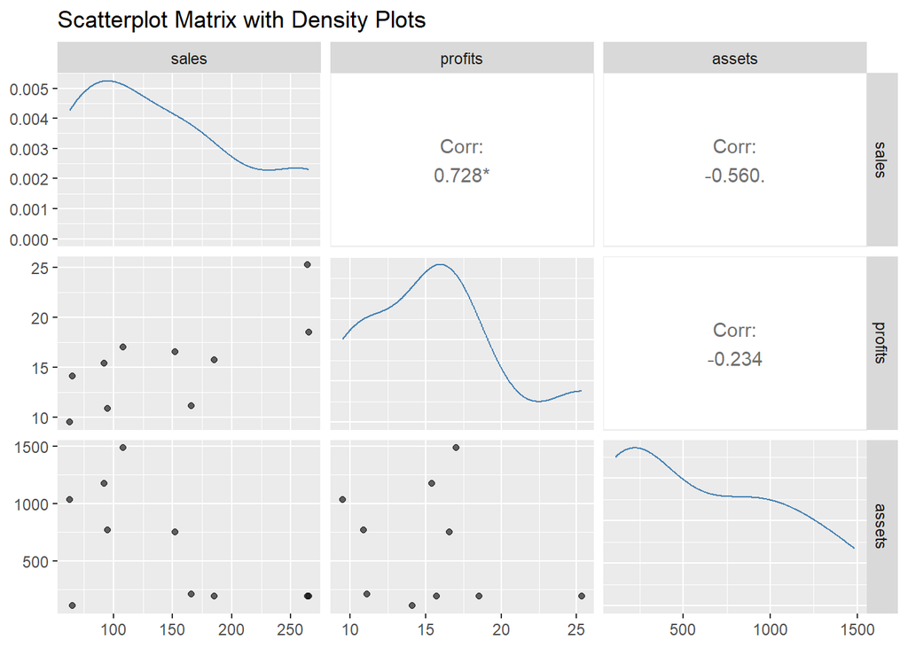

```r
# Creating the pair plot

# Creating a scatterplot matrix with dot plots on diagonals and lower triangular matrix
ggpairs(data = df,
        columns = c("sales", "profits", "assets"),
        title = "Scatterplot Matrix with Density Plots",
        diag = list(continuous = wrap("densityDiag", col = "steelblue")),
        lower = list(continuous = wrap("points", alpha = 0.6)))
```

##### In summary, the above plots shows a positive correlation between sales and profits, aligning with expectations. However, a negative correlation exists between “Sales & Assets” and “Profits & Assets”.

### Histogram Plot

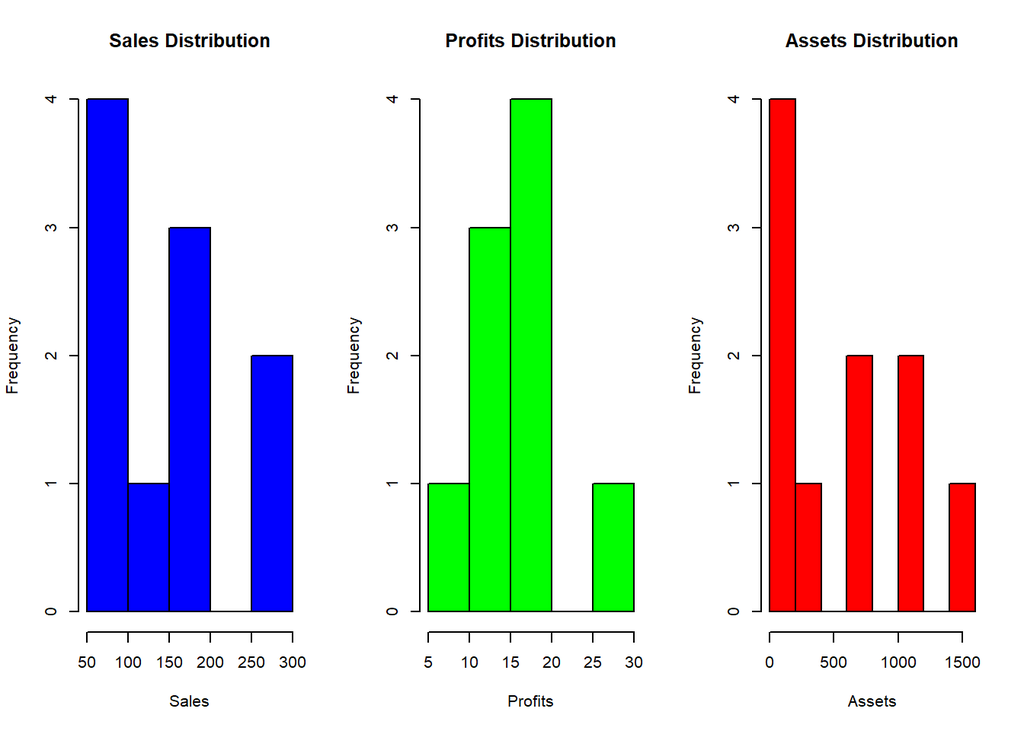

```r
# Creating a new plot window with multiple plots in a 1x3 grid
par(mfrow = c(1, 3))

# Histogram: Sales
hist(data$Sales, col = "blue", main = "Sales Distribution", xlab = "Sales")

# Histogram: Profits
hist(data$Profits, col = "green", main = "Profits Distribution", xlab = "Profits")

# Histogram: Assets
hist(data$Assets, col = "red", main = "Assets Distribution", xlab = "Assets")
```

```r
# Reset plot layout
par(mfrow = c(1, 1))
```

# Box Plot

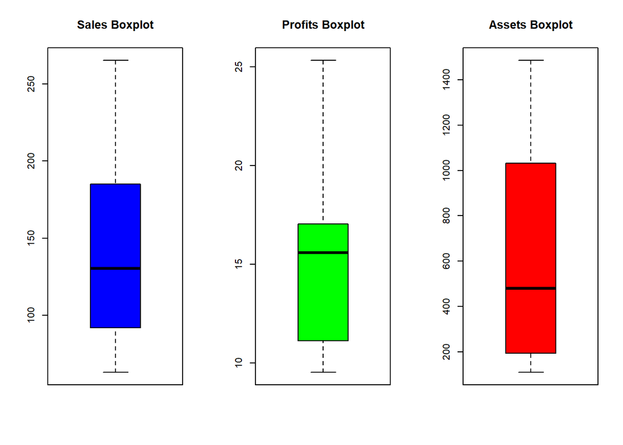

```r
# Creating a new plot window with multiple plots in a 1x3 grid
par(mfrow = c(1, 3))

# Boxplot: Sales
boxplot(df$sales, col = "blue", main = "Sales Boxplot")

# Boxplot: Profits
boxplot(df$profits, col = "green", main = "Profits Boxplot")

# Boxplot: Assets
boxplot(df$assets, col = "red", main = "Assets Boxplot")
```

```r
# Reset plot layout
par(mfrow = c(1, 1))
```

#### This plot shows sales has median of roughly 125 billion, profits a little above 15 billion and assests around 500 billion.

### 3.

### Questions : 1. Which Company has the highest & least Sales, Profits, Assets ?

```r
print(paste("Company with the highest sales:",company[which.max(sales)],
      "& Company with the lowest Sales:",company[which.min(sales)]) )
```

```
## [1] "Company with the highest sales: Royal Dutch/Shell & Company with the lowest Sales: HSBC group"
```

```r
print(paste("Company with the highest Profit:",company[which.max(profits)],
      "& Company with the lowest Profits:",company[which.min(profits)]))
```

```
## [1] "Company with the highest Profit: Exxon Mobil & Company with the lowest Profits: HSBC group"
```

```r
print(paste("Company with the highest Assets:",company[which.max(assets)],
      "& Company with the lowest Assets:",company[which.min(assets)]))
```

```
## [1] "Company with the highest Assets: Citigroup & Company with the lowest Assets: Bank of America"
```

#### Sales Strategy: Given that Royal Dutch/Shell has the highest sales and HSBC group has the lowest, the end user could analyze the factors contributing to Royal Dutch/Shell’s success and consider potential strategies to improve HSBC group’s sales performance. Understanding what sets top performers apart could guide sales strategies.

#### Profit Maximization: Exxon Mobil stands out with the highest profits, while HSBC group lags behind. This discrepancy highlights the importance of analyzing Exxon Mobil’s profitability model and identifying opportunities for the HSBC group to enhance its profit margins.

#### Asset Management: Citigroup leads in asset value, while Bank of America falls behind. The end user could study Citigroup’s effective asset management practices and offer suggestions to Bank of America for optimizing its asset utilization and potentially improving overall financial health.